# Unidad 2: Derivadas

[figure not shown]

Neumático de un dragster al acelerar a fondo. Las derivadas nos permiten estudiar la rapidez con que cambia la velocidad. Fuente: Pinterest.com

## ¿Por qué estudiar derivadas?

Las derivadas son una herramienta poderosa para **entender y predecir cómo cambian las cosas**.

En las carreras de dragsters, dos autos compiten acelerando en línea recta durante solo 305 metros (1/4 de milla). No gana el que tiene mayor velocidad final, sino el que acelera más rápido desde el inicio.

En la vida real hay muchas situaciones que, como en los dragsters, lo importante es la **rapidez con que se pasa de una situación a otra**. Por ejemplo la agresividad de un virus está relacionada con la **rapidez** con que puede infectar un misma cantidad de población.

El estudio preciso de estos fenómenos es posible gracias al cálculo diferencial o derivadas.

## 1. Conceptos Previos

### 1.a) Pendiente de una recta a partir de su gráfica

🔁 Repaso:

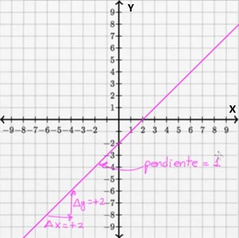

- $\Delta y$ es el cambio en la variable vertical (eje y),
- $\Delta x$ es el cambio en la variable horizontal (eje x),

Puedes repasar esto en este [video](https://es.khanacademy.org/math/algebra/x2f8bb11595b61c86:linear-equations-graphs/x2f8bb11595b61c86:slope/v/positive-and-negative-slope) donde además verás como puede ser positiva y negativa.

📝 Práctica:

Resuelve estos [ejercicios](https://es.khanacademy.org/math/algebra/x2f8bb11595b61c86:linear-equations-graphs/x2f8bb11595b61c86:slope/e/slope-from-a-graph)

### 1.b) Pendiente de una recta a partir de dos puntos

🔁 Repaso:

[figure not shown]

En una recta que pasa por dos puntos $(x_1, y_1)$ y $(x_2, y_2)$, se calcula como: $m = \frac{y_2 - y_1}{x_2 - x_1}$

**Relación con la tangente:** La pendiente de la recta es igual a la tangente del ángulo “α” que forma la recta con la horizontal.

📝 Práctica:

Resuelve estos [ejercicios](https://es.khanacademy.org/math/algebra/x2f8bb11595b61c86:linear-equations-graphs/x2f8bb11595b61c86:slope/e/slope-from-two-points)

### 1.c.) Recta tangente

🔁 Repaso:

[figure not shown]

La recta tangente a una curva en un punto es la recta que:

- toca la curva solo en ese punto (o en un entorno muy pequeño),
- y tiene la misma dirección instantánea que la curva en ese lugar.

> Es como apoyar una regla sobre una curva sin que la atraviese: la dirección que toma la regla en ese punto es la de la recta tangente.

## 2. Definir tasas de cambio promedio e instantáneas en un punto

🔁 Repaso:

- La tasa de cambio promedio se corresponde con la velocidad promedio de Usain Bolt y es una pendiente en la gráfica. Pero la velocidad que tiene realmente en cada instante es distinta a la velocidad promedio. Esta velocidad en cada instante se puede pensar como la tasa instantánea de cambio y coincide con la pendiente de la recta tangente en un punto dado y esto es la derivada. Puedes repasarlo en detalle [aquí](https://www.youtube.com/watch?v=z0pdqj3zH3s).
- La tasa de cambio promedio es la pendiente de una recta secante que pasa por dos puntos. Cuando acercamos más y más los dos puntos la recta secante pasa a ser la recta tangente. Puedes repasarlo [aquí](https://www.youtube.com/watch?v=-9sVJ4--YTE)

📝 Práctica:

Resuelve estos [ejercicios](https://es.khanacademy.org/math/ap-calculus-ab/ab-differentiation-1-new/ab-2-1/e/secants-and-average-rate-of-change) en la carpeta.

## 3. Cálculo de la derivada por definición

🔁 Repaso:

La derivada de una función $f(x)$ en un punto $x = a$ es:

$$f'(a) = \lim_{h \to 0} \frac{f(a + h) - f(a)}{h}$$

**Ejemplo:**

Calcular la derivada de $f(x) = x^2$ en $x = 2$ usando la definición.

$$f'(2) = \lim_{h \to 0} \frac{(2+h)^2 - 4}{h} = \lim_{h \to 0}
\frac{4 + 4h + h^2 - 4}{h} = \lim_{h \to 0} \frac{4h + h^2}{h} = \lim_{h
\to 0}(4 + h) = 4$$

📝 Práctica:

1. Calcula la derivada de $f(x) = 3x + 1$ usando la definición.
2. Calcula la derivada de $f(x) = x^2 + 2x$ en $x = 1$.

## 4. Reglas de derivación

🔁 Repaso:

Recuerda que dada una función $y(x)$ se puede indicar su derivada como $y'$ o como $\frac{dy}{dx}$.

**Tabla de derivadas básicas:**

| Función | Derivada |
| --- | --- |
| $a$ (constante) | $0$ |
| $ax$ | $a$ |
| $x^n$ | $nx^{n-1}$ |
| $\sin x$ | $\cos x$ |
| $\cos x$ | $-\sin x$ |
| $e^x$ | $e^x$ |
| $\ln x$ | $\frac{1}{x}$ |
| $\log_b(x)$ | $\dfrac{1}{x \ln b}$ |
| $a^x$ | $a^x \ln a$ |

**Reglas de combinación:**

Dadas las funciones $f$ y $g$:

- **Suma/resta**: $(f \pm g)' = f' \pm g'$
- **Producto**: $(fg)' = f'g + fg'$
- **Cociente**: $\left(\frac{f}{g}\right)' = \frac{f'g - fg'}{g^2}$

📝 Práctica:

1. Encuentra el error en los cálculos de derivadas [aquí](https://es.khanacademy.org/math/ap-calculus-ab/ab-differentiation-1-new/ab-2-6a/e/differentiating-linear-functions). No hace falta hacerlo en la carpeta.
2. Encuentra estas derivadas de polinomios [aquí](https://es.khanacademy.org/math/ap-calculus-ab/ab-differentiation-1-new/ab-2-6b/e/power-rule-basic).
3. Encuentra estas derivadas donde la x puede aparecer en el denominador [aquí](https://es.khanacademy.org/math/ap-calculus-ab/ab-differentiation-1-new/ab-2-6b/e/differentiate-radical-functions-intro).
4. Encuentra estas derivadas donde aparece senos y cosenos [aquí](https://es.khanacademy.org/math/ap-calculus-ab/ab-differentiation-1-new/ab-2-7/e/differentiate-sine-and-cosine)
5. Aplicar la regla del producto [aquí](https://es.khanacademy.org/math/ap-calculus-ab/ab-differentiation-1-new/ab-2-8/e/differentiate-products).
6. Aplica la regla de la división [aquí](https://es.khanacademy.org/math/ap-calculus-ab/ab-differentiation-1-new/ab-2-9/e/differentiate-quotients).
7. Aplica todo lo aprendido [aquí](https://es.khanacademy.org/math/ap-calculus-ab/ab-differentiation-1-new/ab-2-9/e/differentiate-rational-functions).

## 5. Regla de la cadena

🔁 Repaso:

Se usa cuando hay funciones compuestas:

$$\frac{d}{dx}[f(g(x))] = f'(g(x)) \cdot g'(x)$$

**Ejemplo:**

$$y = \sin(x^2) \Rightarrow y' = \cos(x^2) \cdot 2x$$

Puedes repasarlo [aquí](https://es.khanacademy.org/math/ap-calculus-ab/ab-differentiation-2-new/ab-3-1a/v/chain-rule-introduction). También este [video](https://es.khanacademy.org/math/ap-calculus-ab/ab-differentiation-2-new/ab-3-1a/v/common-chain-rule-misunderstandings) te va a orientar sobre algunos errores comunes.

📝 Práctica:

1. Resuelve estos 4 [ejercicios](https://es.khanacademy.org/math/ap-calculus-ab/ab-differentiation-2-new/ab-3-1a/e/differentiate-composite-functions-intro)
2. Resuelve:
   - **a)** $f(x) = (3x + 2)^4$
   - **b)** $f(x) = \sin(5x^2)$
   - **c)** $f(x) = e^{\ln(x^2 + 1)}$
   - **d)** $f(x) = \sqrt{\tan(2x)}$
   - **e)** $f(x) = \ln\left[\left(2x^2 + 3\right)^5 \cdot \sqrt{\sin x}\right]$

## 6. Regla de L’Hôpital

🔁 Repaso:

Se usa en límites indeterminados como $\frac{0}{0}$ o $\frac{\infty}{\infty}$.

$$\lim_{x \to a} \frac{f(x)}{g(x)} = \lim_{x \to a}
\frac{f'(x)}{g'(x)} \quad \text{(si el límite existe)}$$

**Ejemplo:**

$$\lim_{x \to 0} \frac{\sin x}{x} = \frac{\cos x}{1} = 1$$

También puedes repasarlo [aquí](https://www.youtube.com/watch?v=vJ5V9U2mMP8&t=483s).

📝 Práctica:

Resuelve:

1. $\lim_{x \to \infty} \frac{x}{e^x}$
2. $\lim_{x \to 0} \frac{\tan(3x)}{x}$
3. $\lim_{x \to 0} \frac{e^{2x} - 1}{\sin x}$
4. $\lim_{x \to 0} \frac{\ln(\cos(2x))}{x^2}$
5. $\lim_{x \to 0} \frac{e^{\tan x} - 1 - \tan x}{x^2}$
6. $\lim_{x \to 0} \frac{\ln(1 + \sin^2(2x))}{x^2}$
7. $\lim_{x \to 0} \frac{e^{\sin^2(2x)} - 1}{x^2}$

## 7. Máximos y mínimos relativos de una función

🔁 Repaso:

- **Máximo relativo**: un punto donde el valor de la función es mayor que los valores cercanos a él.
- **Mínimo relativo**: un punto donde el valor de la función es menor que los valores cercanos a él.
- Puedes repasarlo [aquí](https://www.youtube.com/watch?v=K5DrUur2HgU&t=267s)

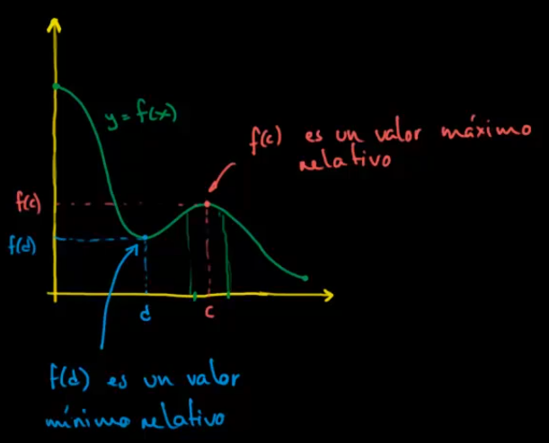

Fuente: Khan Academy

- **Punto crítico**: Un valor $x_0$ es un punto crítico de la función $f(x)$ si, en ese punto, la pendiente de la gráfica es **cero** o **no existe**.
  - **Pendiente nula**: la recta tangente en ese punto es horizontal, lo que equivale a que la derivada vale cero.
  - **Pendiente no definida**: la gráfica presenta un cambio brusco de dirección (como una cúspide) o una tangente vertical, por lo que no se puede asignar un valor de pendiente.
- Se puede afirmar: Si una función tiene un máximo o mínimo relativo en $x_0$, entonces $x_0$ es un punto crítico, es decir, $f'(x_0) = 0$ **o** $f'(x_0)$ no existe.
- Puedes repasarlo también [aquí](https://es.khanacademy.org/math/ap-calculus-ab/ab-diff-analytical-applications-new/ab-5-4/v/testing-critical-points-for-local-extrema)

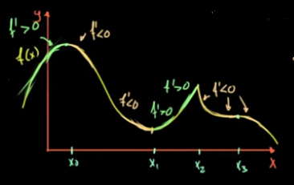

Fuente: Khan Academy

- Pasos para encontrar máximos o mínimos relatios de una función:
  - Derivar la función: $f'(x)$
  - Igualar a cero: $f'(x) = 0$
  - Analizar los signos de la derivada antes y después del punto crítico
- Análisis de los signos de la derivada:
  - Si $f'(x)$ **cambia de + a −** en $x_0$ → **máximo**.
  - Si $f'(x)$ **cambia de − a +** en $x_0$ → **mínimo**.
  - Si no cambia de signo → no hay máximo ni mínimo.

**Ejemplo:**

$f(x) = -x^2 + 4x$

- $f'(x) = -2x + 4$
- $f'(x) = 0 \Rightarrow x = 2$
- Máximo relativo en $x=2$, ya que cambia de positivo a negativo.

Puedes repasar esto también [aquí](https://es.khanacademy.org/math/ap-calculus-ab/ab-diff-analytical-applications-new/ab-5-4/v/finding-relative-maximum-example)

📝 Práctica:

Encontrar los puntos críticos de las siguientes funciones y analizar si corresponden a máximos o mínimos relativos

1. $f(x) = x^2 - 4x + 3$
2. $f(x) = x^3 - 3x^2 + 2$
3. $g(x) = -2x^3 + 3x^2 + 12x - 5$

## 8. Problemas de optimización

🔁 Repaso:

**Problema:** Un granjero quiere construir un corral rectangular junto a un muro, de modo que no necesite cercar el lado que da al muro. Si tiene 48 metros de cerca para usar en los otros tres lados, ¿qué dimensiones debe tener el corral para que el área sea máxima?

**Planteo**

- Sea $x$ el ancho (lado perpendicular al muro).
- Sea $y$ el largo (lado paralelo al muro).

El lado junto al muro no necesita cerca. Entonces, el perímetro con cerca es:

$$2x + y = 48$$

Queremos maximizar el área:

$$A = x \cdot y$$

**Resolución**

- Expresar $y$ en función de $x$: $y = 48 - 2x$
- Función área en función de $x$: $A(x) = x \cdot (48 - 2x) = 48x - 2x^2$
- Derivar $A(x)$: $A'(x) = 48 - 4x$
- Encontrar puntos críticos: $A'(x) = 0 \implies 48 - 4x = 0 \implies x = 12$
- Determinar máximo o mínimo:
  - Antes de x=12: $A'(10) = 48 - 40 = 8$ Signo positivo
  - Luego de x=12: $A'(14) = 48 - 56 = -8$ Signo negativo
  - Como pasa de + a - hay un **máximo relativo**
- Encontrar $y$: $y = 48 - 2(12) = 48 - 24 = 24$

**Respuesta:**

Para maximizar el área, el corral debe tener:

- Ancho $x = 12$ metros
- Largo $y = 24$ metros

📝 Práctica:

Resolver el siguiente problema: Se desea fabricar una caja sin tapa con un volumen de 32 m³. La base es cuadrada. ¿Qué dimensiones minimizan la cantidad de material usado?